# Tests for distributions

[Dr. Peng Zhao](https://connect.xjtlu.edu.cn/user/pengzhao) (✉ peng.zhao@xjtlu.edu.cn)

Department of Health and Environmental Sciences  
Xi’an Jiaotong-Liverpool University

# 1 Learning objective

1. Understand the relationship between the R distribution functions.
2. Understand the Kolmogorov-Smirnov distribution and the Kolmogorov-Smirnov test statistic.
3. Use the Kolmogorov-Smirnov test for one-sample and two-sample hypothesis tests.

# 2 Distributions and their R functions

| Distribution | `p-` | `q-` | `d-` | `r-` |
| --- | --- | --- | --- | --- |
| Beta | `pbeta` | `qbeta` | `dbeta` | `rbeta` |
| Binomial | `pbinom` | `qbinom` | `dbinom` | `rbinom` |
| Cauchy | `pcauchy` | `qcauchy` | `dcauchy` | `rcauchy` |
| Chi-Square | `pchisq` | `qchisq` | `dchisq` | `rchisq` |
| Exponential) | `pexp` | `qexp` | `dexp` | `rexp` |
| F | `pf` | `qf` | `df` | `rf` |
| Gamma | `pgamma` | `qgamma` | `dgamma` | `rgamma` |
| Geometric | `pgeom` | `qgeom` | `dgeom` | `rgeom` |
| Hypergeometrictm | `phyper` | `qhyper` | `dhyper` | `rhyper` |
| Logistic | `plogis` | `qlogis` | `dlogis` | `rlogis` |
| Log Normal | `plnorm` | `qlnorm` | `dlnorm` | `rlnorm` |
| Negative Binomial | `pnbinom` | `qnbinom` | `dnbinom` | `rnbinom` |
| Normal | `pnorm` | `qnorm` | `dnorm` | `rnorm` |
| Poisson | `ppois` | `qpois` | `dpois` | `rpois` |
| Student t | `pt` | `qt` | `dt` | `rt` |
| Studentized Range | `ptukey` | `qtukey` | `dtukey` | `rtukey` |
| Uniform | `punif` | `qunif` | `dunif` | `runif` |
| Weibull | `pweibull` | `qweibull` | `dweibull` | `rweibull` |
| Wilcoxon Rank Sum Statistic | `pwilcox` | `qwilcox` | `dwilcox` | `rwilcox` |
| Wilcoxon Signed Rank Statistic | `psignrank` | `qsignrank` | `dsignrank` | `rsignrank` |

Distribution functions in R: prefix + root_name

- `d` for “density”, the density function (PDF).
- `p` for “probability”, the cumulative distribution function (CDF).
- `q` for “quantile” or “critical”, the inverse of CDF.
- `r` for “random”, a random variable having the specified distribution

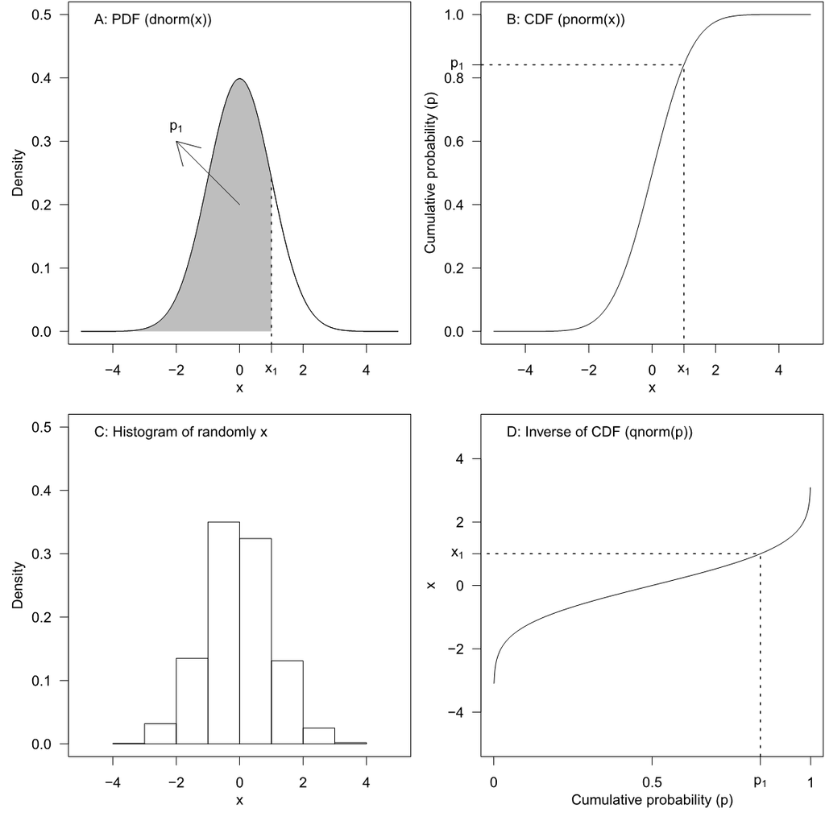

| Distribution | Parameters | Expression | Mean | Variance |
| --- | --- | --- | --- | --- |
| Bernoulli trial | $p$ | $p$ | $p$ | $pq$ |
| Binomial | $n, p$ | $C(n, x) p^x q^{n-x}$ | $np$ | $npq$ |
| Poisson | $\lambda$ | $e^{-\lambda} \lambda^x / x !$ | $\lambda$ | $\lambda$ |
| Normal | $\mu, \sigma$ | $\frac{1}{\sqrt{2 \pi \sigma}} e^{-(x-\mu)^2 / 2 \sigma^2}$ | $\mu$ | $\sigma^2$ |
| Std. Normal | $z$ | $\frac{1}{\sqrt{2 \pi}} e^{-z^2 / 2}$ | 0 | 1 |
| t | $v$ | $\frac{\Gamma\left(\frac{v+1}{2}\right)}{\sqrt{v \pi} \Gamma\left(\frac{v}{2}\right)}\left(1+\frac{x^2}{v}\right)^{-\frac{v+1}{2}}$ | 0 | $\left\{\begin{array}{cc}v /(v-2) & \text { for } v>2 \\ \infty & \text { for } 1<v \leq 2 \\ \text { undefined } & \text { otherwise }\end{array}\right.$ |

# 3 Empirical distribution function (EDF or eCDF)

## 3.1 Definition

Given an observed random sample ${X_{1}}$, ${X_{2}}$, …, ${X_{n}}$, an empirical distribution function ${F_{n}}(X)$ is the fraction of sample observations less than or equal to the value x. More specifically, if ${y_{1}}$<${y_{2}}$<..<${y_{n}}$ are the order statistics of the observed random sample, with no two observations being equal, then the empirical distribution function is defined as:

$F_{n}(x)= \begin{cases}0, & \text { for } x<y_{1} \\ k / n, & \text { for } y_{k} \leqslant x<y_{k+1}, k=1,2, \ldots, n-1 \\ 1, & \text { for } x \geqslant y_{n}\end{cases}$

Commonly also called empirical Cumulative Distribution Function.

## 3.2 Example: normal distribution

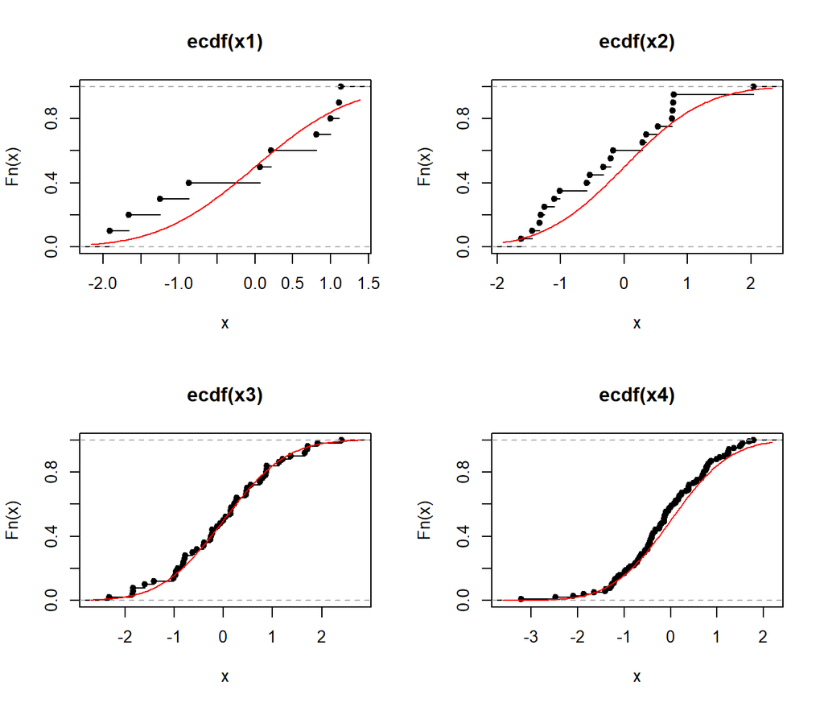

```r
par(mfrow = c(2, 2))
x1 <- rnorm(10)
x2 <- rnorm(20)
x3 <- rnorm(50)
x4 <- rnorm(100)
plot(ecdf(x1))
curve(pnorm, col = 'red', add = TRUE)
plot(ecdf(x2))
curve(pnorm, col = 'red', add = TRUE)
plot(ecdf(x3))
curve(pnorm, col = 'red', add = TRUE)
plot(ecdf(x4))
curve(pnorm, col = 'red', add = TRUE)
```

# 4 Kolmogorov-Smirnov test

## 4.1 Principle

Kolmogorov-Smirnov distribution

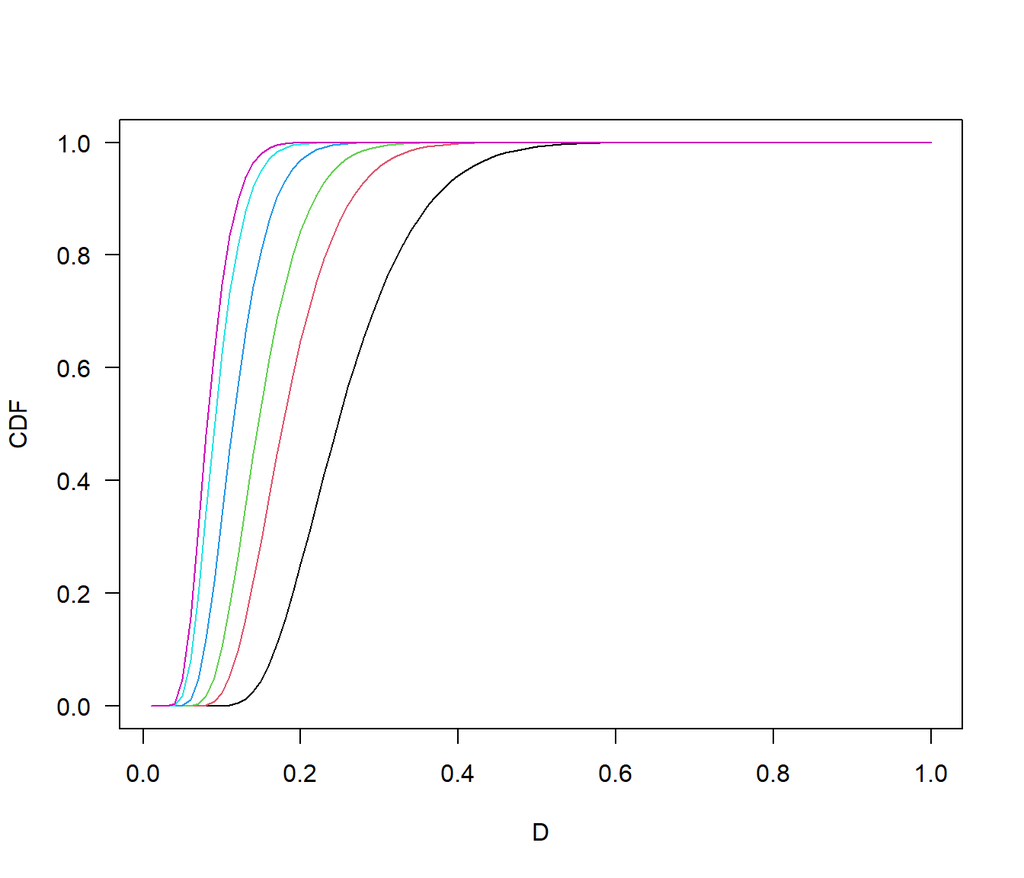

```r
# Install the kolmin package locally.
library(kolmim)
pvalue <- pkolm(d = 0.1, n = 30)
nks <- c(10, 20, 30, 50, 80, 100)
x <- seq(0.01, 1, 0.01)
y <- sapply(x, pkolm, n = nks[1])
plot(x, y, type = 'l', las = 1, xlab = 'D', ylab = 'CDF')
for (i in 2:length(nks)) lines(x, sapply(x, pkolm, n = nks[i]), col = i)
```

critical values for D for one sample ($n\le40$):

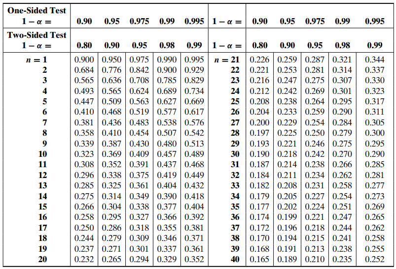

Table of one-sample Kolmogorov-Smirnov test statistics D

[output not shown]

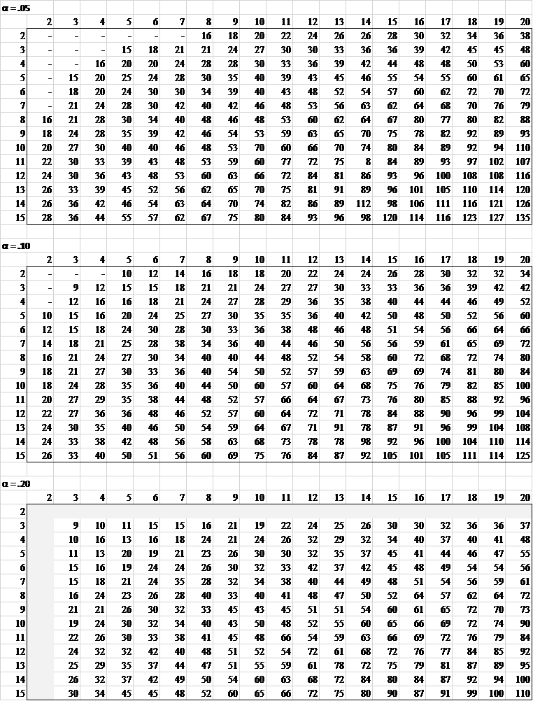

Table of two-sample Kolmogorov-Smirnov test statistics D

[output not shown]

## 4.2 One-sample test

Hypothesis:

$H_{0}: F(x)=F_{0}(x)$ The CDF of x is a given reference distribution function $F_0(x)$.

Test statistic:

$D_{n}=\sup _{x}\left[\left|F_{n}(x)-F_{0}(x)\right|\right]$

$D_{n}$: the supremum distance between the empirical distribution function of given sample and the cumulative distribution function of the given reference distribution.

Example:

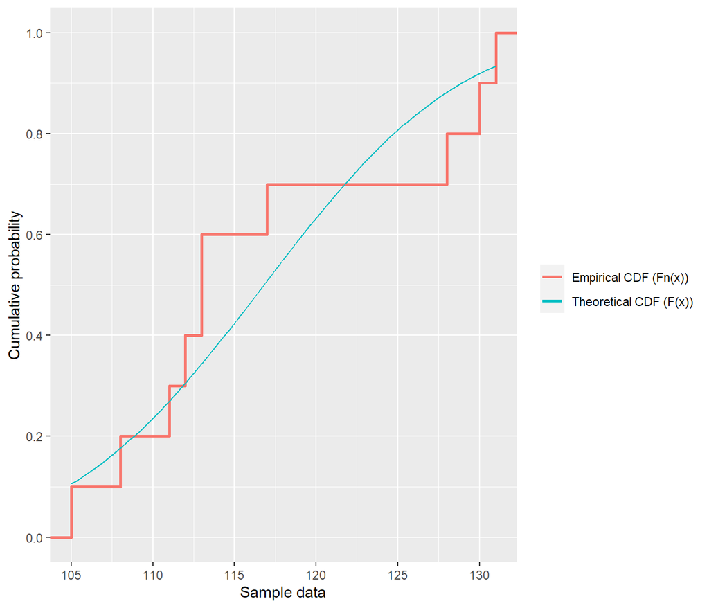

```r
x0 <- c(108, 112, 117, 130, 111, 131, 113, 113, 105, 128)
x0_mean <- mean(x0)
x0_sd <- sd(x0)
eCDF <- ecdf(x0)

# cumulative distribution function F(x) of the reference distribution
CDF <- pnorm(x0, x0_mean, x0_sd)

# create a data frame to put values into
df <- data.frame(data = x0, eCDF = eCDF(x0), CDF = CDF)

# visualization
library(ggplot2)
ggplot(df, aes(data)) +
  stat_ecdf(size=1,aes(colour = "Empirical CDF (Fn(x))")) +
  stat_function(fun = pnorm, args = list(x0_mean, x0_sd), aes(colour = "Theoretical CDF (F(x))")) +
  xlab("Sample data") +
  ylab("Cumulative probability") +
  scale_y_continuous(breaks=seq(0, 1, by = 0.2))+
  theme(legend.title=element_blank())
```

```r
# sort values of sample observations and remove duplicates
x <- unique(sort(x0))

# Calculate D
Daft <- abs(eCDF(x) - pnorm(x, x0_mean, x0_sd))
Dbef <- abs(c(0, eCDF(x)[-length(x)]) - pnorm(x, x0_mean, x0_sd))
D_score <- max(c(Daft, Dbef))
```

**One step in R:**

```r
ks.test(x0,'pnorm', x0_mean, x0_sd)
```

```
    Asymptotic one-sample Kolmogorov-Smirnov test

data:  x0
D = 0.25621, p-value = 0.5276
alternative hypothesis: two-sided
```

## 4.3 Two-sample test

Hypothesis:

$H_0$: Two populations follow a common probability distribution.

Test statistic:

$D_{n,m}=\sup _{x}\left[\left|F_{1, n}(x)-F_{2, m}(x)\right|\right]$

Example:

```r
sample1 <- c(165, 168, 172, 177, 180, 182)
sample2 <- c(163, 167, 169, 175, 175, 179, 183, 185)
mean1 <- mean(sample1)
mean2 <- mean(sample2)
sd1 <- sd(sample1)
sd2 <- sd(sample2)

# empirical distribution function Fn(x)
eCDF1 <- ecdf(sample1)
eCDF1(sample1)
```

```
[1] 0.1666667 0.3333333 0.5000000 0.6666667 0.8333333 1.0000000
```

```r
# empirical distribution function Fm(x)
eCDF2 <- ecdf(sample2)
eCDF2(sample2)
```

```
[1] 0.125 0.250 0.375 0.625 0.625 0.750 0.875 1.000
```

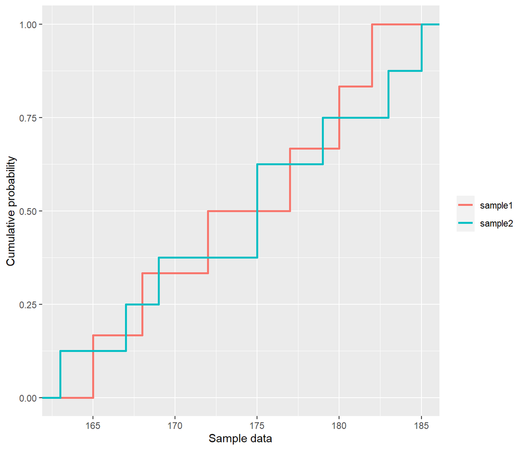

```r
# visualization
group2 <- c(rep("sample1", length(sample1)), rep("sample2", length(sample2)))
df2 <- data.frame(all = c(sample1,sample2), group = group2)
library(ggplot2)
ggplot(df2, aes(x = all, group = group, color = group2)) +
  stat_ecdf(size=1) +
  xlab("Sample data") +
  ylab("Cumulative probability") +
  theme(legend.title=element_blank())
```

```r
# merge, sort observations of two samples, and remove duplicates
x2 <- unique(sort(c(sample1,sample2)))

# calculate D and its location
D2 <- max(abs(eCDF1(x2) - eCDF2(x2)))
idxD2 <- which.max(abs(eCDF1(x2) - eCDF2(x2))) # the index of x-axis value
xD2 <- x2[idxD2] # corresponding x-axis value
```

**One step in R:**

```r
ks.test(sample1, sample2)
```

```
    Exact two-sample Kolmogorov-Smirnov test

data:  sample1 and sample2
D = 0.25, p-value = 0.9281
alternative hypothesis: two-sided
```

# 5 Further readings

- The R book. Chapter 8.10.

# 6 Exercises

1. Based on the data set *state.x77*, dose the murder rate follow a normal distribution?
2. Based on the iris dataset, does the sepal width of versicolor follow the same probability distribution as virginica?